# Simple Linear Regression

Scatterplot, Correlation, Regression

Ranadeep Daw

2024-09-17

## Bivariate Data

- So far, you have mostly dealt with univariate data.
- Given one random variable, you calculated the summary statistics – **mean, median**, **quantile**, **variance**, **IQR**, etc.
- You have done some inference – **estimation**, **hypothesis testing**, **confidence interval**.
- Some introduction to two-sample data – **independent** and **paired** cases.

## Bivariate Data

- Now we extend our analysis to bivariate data, i.e., two random variables.
- Like the paired t-test case, we have twos sets of data about $n$ subjects:

| Subject | X | Y |
| --- | --- | --- |
| Subject 1 | $x_1$ | $y_1$ |
| Subject 2 | $x_2$ | $y_2$ |
| $\ldots$ | $\ldots$ | $\ldots$ |
| Subject n | $x_n$ | $y_n$ |

## Separate Univariate Analysis

- Following our univariate lectures, we can analyze each variable X and Y separately.
  - Can calculate $\bar{x}$, $\bar{y}$, $s^2_{X}$, $s^2_{Y}$.
- Is that enough to complete even a basic-level analysis?
  - No
- What are we missing?

## Case study

- | **Case 1:** |  |  |  |  |  |
  | --- | --- | --- | --- | --- | --- |
  | X | -2 | -1 | 0 | 1 | 2 |
  | Y | -2 | -1 | 0 | 1 | 2 |

- | **Case 2:** |  |  |  |  |  |
  | --- | --- | --- | --- | --- | --- |
  | X | -2 | -1 | 0 | 1 | 2 |
  | Y | 2 | 1 | 0 | -1 | -2 |

- In each case, $\bar{X}$ = 0; $\bar{Y}$ = 0; $s^2_X$ = 2.5; $s^2_Y$ = 2.5.
- So, what are we missing so far?

## Goals for Analysis

- We want to explore the **relationship** between these two variables.
- Specifically, we will look at **linear relationship** for now.
- **Question**: If there is a relation, can we predict one variable based on the other?

## Scatterplot

- *Definition*: A graphical representation that helps visualize the relationship between two quantitative variables. Each point on the plot represents an observation in the dataset.
- Plot one variable against the other one.
- One variable (say X) on the $X$ axis, the other (say Y) is on the $Y$ axis. The points on the plot are the coordinates $(x_1, y_1), (x_2, y_2) , \ldots, (x_n, y_n)$.

## Syntax

- $\texttt{R}$ Syntax: plot(<vector_x>, <vector_y>)

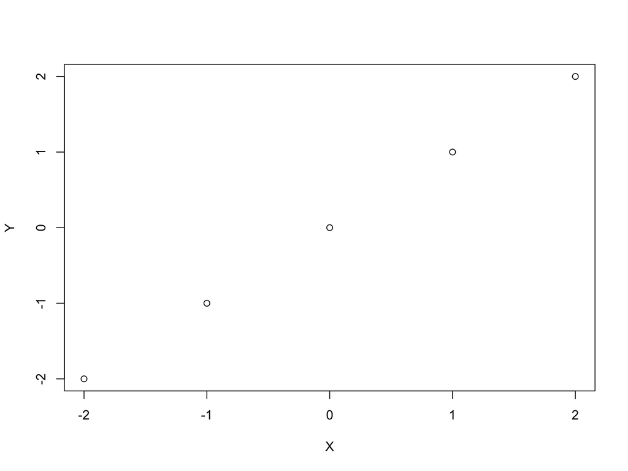

```r
X = c(-2, -1, 0, 1, 2)
Y = c(-2, -1, 0, 1, 2)
plot(X, Y)
```

## Example from $\texttt{mtcars}$ Data

- Scatterplot between the displacement (column name = **disp**) and mpg (column name = **mpg**) from $\texttt{mtcars}$ data.

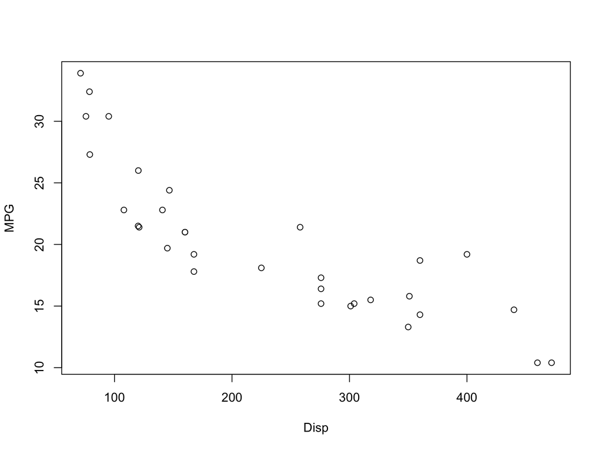

```r
data("mtcars")
Disp = mtcars$disp
MPG = mtcars$mpg
plot(Disp, MPG)
```

## Case study: Contd.

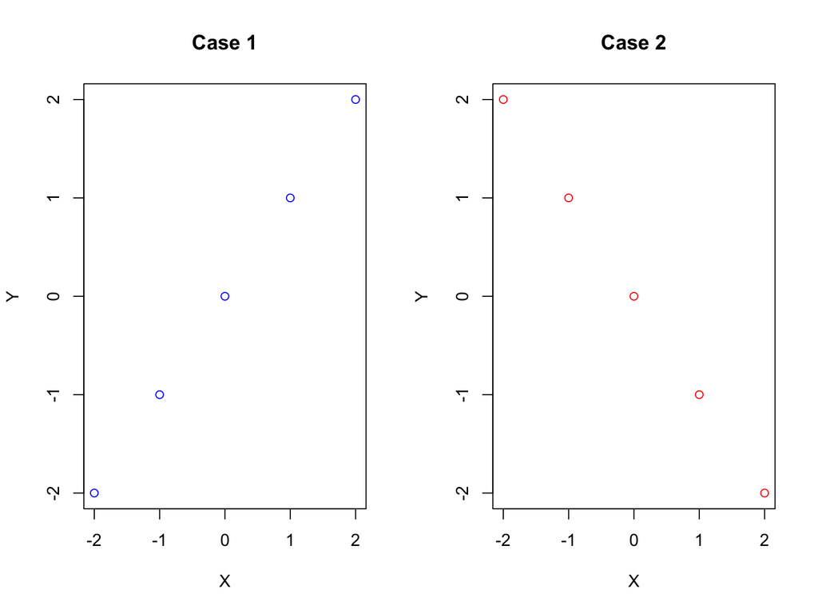

## Relationships

- Do you see the difference in relationships now in the two plots?
- Case 1: **Positive/Increasing pattern**: As one variable increases, the other tends to increase.
- Case 2: **Negative/Decreasing pattern**: As one variable increases, the other tends to decrease.
- A further case can also arise where no pattern may show in the data, i.e., no apparent relationship between X and Y.

## Covarinace

- *Definition*:
  $$\text{cov}(X, Y) =
  \frac{1}{n-1} \sum_{i=1}^n (x_i - \bar{x}) (y_i - \bar{y})$$
- Can only measure **linear relationship**.
- Positive value indicates a positive linear relationship.
- Negative value indicates a negative linear relationship.
- Covariance near 0 indicates either no linear relationship.

## Examples

- Example of Case 1: cov(X, Y) = 2.5.
  - *Positive relationship:* X increasing indicates Y increasing.
- Example of Case 2: cov(X, Y) = -2.5.
  - *Negative relationship:* X increasing indicates Y decreasing.

## Case 3

- | **Case 3:** |  |  |  |  |  |
  | --- | --- | --- | --- | --- | --- |
  | X | -2 | -1 | 0 | 1 | 2 |
  | Y | -1 | 0 | 2 | 0 | -1 |

- $\bar{X}$ = 0; $\bar{Y}$ = 0; $s^2_X$ = 2.5; $s^2_Y$ = 1.5.
- cov($X, Y$) = 0.

## Cont.

[figure not shown]

- It looks like there is a relationship between $X$ and $Y$; but covariance can’t find it.
- Covariance can only measure **linear relationship**.

## Correlation/ Pearson’s Correlation

- *Definition*:
  $$\text{cor}(X, Y) =
  \frac{1}{n-1} \sum_{i=1}^n \Big(\frac{x_i -
  \bar{x}}{s_X}\Big) \Big(\frac{y_i - \bar{y}}{s_Y}\Big) =
  \frac{\text{cov}(X, Y)} { s_X \,s_Y }$$
- Correlation is unit free
- $-1 \leq \text{cor}(X, Y) \leq 1$.
- Again, can only measure **linear relationship**.
  - Positive values <=> Increasing trend.
  - Negative values <=> Decreasing trend.
  - Values near $0$ <=> No linear relationship.

## $\texttt{R}$ Syntax:

```r
cov(<vector_x>, <vector_y>)  # For covariance
cor(<vector_x>, <vector_y>)  # For correlationship
```

- Example:

```r
X = c(-2, -1, 0, 1, 2)
Y = c(-2, -1, 0, 1, 2)
cov(X, Y)
```

```
## [1] 2.5
```

```r
cor(X, Y)
```

```
## [1] 1
```

## Example from $\texttt{mtcars}$ data

- Calculate covariance and correlation between displacement (column name = **disp**) and mpg (column name = **mpg**) from $\texttt{mtcars}$ data.

```r
data("mtcars")
Disp = mtcars$disp
MPG = mtcars$mpg
cov(Disp, MPG)
```

```
## [1] -633.0972
```

```r
cor(Disp, MPG)
```

```
## [1] -0.8475514
```

## Example from $\texttt{mtcars}$ data

- Calculate covariance and correlation between Rear axle ratio (column name = **drat**) and mpg (column name = **mpg**) from $\texttt{mtcars}$ data.

```r
data("mtcars")
Drat = mtcars$drat
MPG = mtcars$mpg
cov(Drat, MPG)
```

```
## [1] 2.195064
```

```r
cor(Drat, MPG)
```

```
## [1] 0.6811719
```

## Difference between covariance and correlation

- Covariance can be any value between $-\infty$ and $\infty$.
- So, covariance can’t measure the strength of linear relationship. Only when it’s near 0, you know that there is no strong linear relationship.
- However, correlation is bound between $-1$ and $+1$.
- Values near +1 and -1 shows strong linear relationship.

## Spearman’s Rank Correlation Coefficient

- An alternate choice of Pearson’s correlation coefficient.
- A better choice if the data has outliers, ordinal data, or has nonlinear monotonicity.
- Also has a range between $-1$ and $+1$.

## Definition

- From sample X and Y, it first creates two sets of ranks.
  - $R_X = \{r_{x1}, r_{x2}, \ldots, r_{xn} \}$
  - $R_Y = \{r_{y1}, r_{y2}, \ldots, r_{yn} \}$
- The Spearman’s rank correlation coefficient is defined by:

  $$\rho_{s} = \text{cor} (R_X,
  R_Y)$$

## Contd.

- Let’s calculate the differences between the ranks:
  - $R_X = \{r_{x1}, r_{x2}, \ldots, r_{xn} \}$
  - $R_Y = \{r_{y1}, r_{y2}, \ldots, r_{yn} \}$
  - $d_1 = r_{x1} - r_{y1}; \ldots; d_n = r_{xn} - r_{yn}$.
- We can show that:
  - $$\rho_{s} = 1 - \frac{6 \sum_{i=1}^n
    d_i^2}{n(n^2 - 1)}$$

## Example:

Take the following data:

| X | 85 | 90 | 78 | 65 | 70 |
| --- | --- | --- | --- | --- | --- |
| Y | 80 | 78 | 65 | 50 | 55 |

First, rank them and calculate the difference.

| X | 85 | 90 | 78 | 65 | 70 |
| --- | --- | --- | --- | --- | --- |
| $R_X$ | 4 | 5 | 3 | 1 | 2 |
| Y | 80 | 78 | 65 | 50 | 55 |
| $R_Y$ | 5 | 4 | 3 | 1 | 2 |
| $D$ | 1 | 1 | 0 | 0 | 0 |

## Contd.

- Now, use the formula.
- Note: n = 5.
- Also, $\sum_{i=1}^n d_i^2$ = 2.
- So, $\rho_{s} = 1 - \frac{6 \sum_{i=1}^n d_i^2}{n(n^2 - 1)} = 1 - \frac{6 * 2}{5(5^2-1)} = 0.9$.

## $\texttt{R}$ Syntax:

- Syntax: cor(<vector_x>, <vector_y>, method = “spearman”).

```r
x = c(85, 90, 78, 65, 70 )
y = c(80, 78, 65, 50, 55)
cor(x, y, method = "spearman")
```

```
## [1] 0.9
```

## Regression

- The most commonly used statistical model.
  - **Model?**: A mathematical framework to impose some structure on any data or realtionship between data. Helps us analyze the data and make prediction.
  - Example: I can model next year’s temperature from this year’s temperature.
  - Example: I can model a population distribution with normal($\mu, \sigma^2)$.
- When there is a good linear relationship, we can use a simple linear regression model to predict one variable using the other.

## Dependent vs Independent variable

- The variable we want to predict is called the **dependent variable** or **response variable**.
- The variable that helps us in this prediction job is the **independent variable** or **feature** or **covariates**.
- We typically use $X$ for the independent variable; $Y$ for the dependent one.

## Linear relationship

- A line in two dinmension is represented by the set of points $(x,y)$ satisfying an equation: $y = mx + c$;
- Similarly, a perfect relationship will have a similar form: $y = \beta_0 + \beta_1 x$.
- You saw two examples of that already – case 1 and case 2 from before.

## Examples

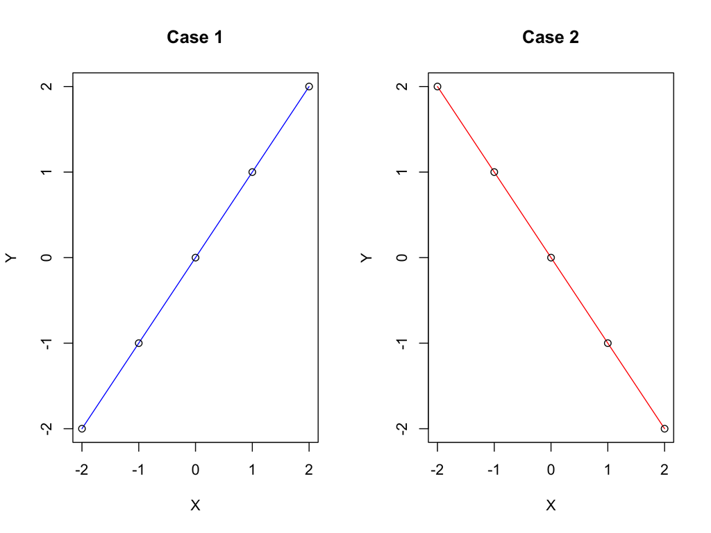

## Linear relationship (cont.)

- In reality, you will never find a perfect linear relationship.
- Instead, if you are lucky, you will find data that will show you the positive or negative trend.
- Example? Check the plots from $\texttt{mtcars}$.

## Example: X = weight (column $\texttt{wt}$); Y = mpg from $\texttt{mtcars}$ data

[figure not shown]

## Simple Linear Regression Model

- Model:
  $$y = \beta_0 + \beta_1 x +
  \epsilon_i$$
- $\epsilon_i$-s are called the **error** terms.
- We make an assumption that $\mathbb{E}(\epsilon_i) = 0$; var$(\epsilon_i) = \sigma^2$.

## What are the parameters here?

- $\beta_0$, $\beta_1$, $\sigma^2$.
- Next class: We will estimate $\beta_0$, $\beta_1$, and $\sigma^2$ based on the data $\mathbb{X} = \{X_1, \ldots, X_n\}; \mathbb{Y} = \{Y_1, \ldots, Y_n\}$.